# Teste de Hipóteses: Introdução

Fernando B. Sabino da Silva

# Inferência Estatística: Hipóteses e teste

## Conceito de hipóteses

- Uma **hipótese** é uma afirmação sobre uma dada população. Geralmente, é uma declaração sobre o valor de um parâmetro populacional (ou sobre o intervalo onde eles estão).
- Exemplos:
  - Controle de qualidade de produtos: Uma hipótese é que os produtos tenham, por exemplo, um determinado peso, um determinado consumo de energia ou uma determinada durabilidade mínima.
  - Economia: Por exemplo, não há dependência entre a idade de uma empresa e o nível de retorno.

## Teste de significância

- Um teste de significância é usado para investigar se os dados contradizem uma hipótese ou não. Lembre-se do que estudamos sobre distribuições amostrais. A ideia aqui é usar as informações de maneira efetiva para poder tomar decisões mais educadas e com maior precisão.
- Se a hipótese diz que um parâmetro assume determinado valor, então o teste deve dizer qual a probabilidade de que uma determinada amostra retirada desta população hipotética gere uma amostra com as características encontradas. Exemplo: Se $\mu = 10$, qual a probabilidade de que uma amostra retirada desta população apresente $\bar{X}_n = 8$? Se a probabilidade for grande, não iremos descartar a hipótese e diremos (ficará mais claro adiante) que “não há evidências suficientes para que rejeitemos a hipótese”. Se a probabilidade for pequena, fará mais sentido imaginarmos que a amostra foi retirada de outra população (não foi retirada da hipotética). Qual população? Uma que tenha mais probabilidade de ter gerado aquela amostra.
- Exemplos:
  - Tempo de espera em uma fila. Nós coletamos uma amostra de $n$ clientes e contamos quantos esperaram mais de 5 minutos. A política da empresa é de que no máximo $10\%$ dos clientes devem esperar mais do que 5 minutos. Em uma amostra de tamanho $n=32$, nós observamos 4 com tempo de espera superior a 5 minutos, i.e. a proporção estimada é de $\hat{p} = \frac{4}{32} = 12.5\%$. Sabendo que $\hat{p}$ depende da amostra, podemos nos perguntar se o valor encontrado é significativamente diferente de $10\%$? Em outras palavras, se a proporção populacional é de fato $10\%$, qual a probabilidade de encontrarmos $12.5\%$ em uma amostra de 32 clientes?
  - O nível de álcool no sangue de um estudante é medido 4 vezes e apresenta os seguintes valores $0.504,0.500,0.512,0.524$, i.e. a média estimada é $\bar{y}=0.51$. Isto é muito diferente de, digamos, um limite de $0.5$?

## Hipótese nula e alternativa

- **A hipótese nula** - denotada por $H_0$ - geralmente especifica que um parâmetro da população tem algum valor determinado. Por exemplo, se $\mu$ é a média do nível de álcool no sangue, nós podemos escrever a hipótese nula como
  - $H_0 : \mu = 0.5$.
- A **hipótese alternativa** - denotada por $H_1$ - especifica que o parâmetro populacional está contido em um conjunto de valores diferentes do especificado na hipótese nula. Por exemplo,
  - a hipótese nula é $H_0 : \mu = 0.5$
  - a hipótese alternativa é $H_1 : \mu \neq 0.5$.
- A **hipótese alternativa** - denotada $H_1$ - geralmente especifica que o parâmetro populacional está contido em um dado conjunto de valores diferentes da hipótese nula. Por exemplo, se $\mu$ é a média populacional de uma medição do nível de álcool no sangue,
- a hipótese nula é $H_0: \mu = 0.5$
- a hipótese alternativa é $H_1: \mu \neq 0.5$.

## Estatística de teste

- Considere um parâmetro populacional $\mu$ e
  $$H_0:\mu = \mu_0,$$
  onde $\mu_0$ é um número conhecido, digamos, $\mu_0 = 0.5$.
- Com base na amostra, nós temos uma estimativa $\hat{\mu}$.
- Uma **estatística de teste** $T$ dependerá tipicamente de $\hat{\mu}$ e $\mu_0$ (podemos escrever $T(\hat{\mu}, \mu_0)$) e medirá quão “longe $\hat{\mu}$ está de $\mu_0$”
- Frequentemente nós usamos $T(\hat{\mu},\mu_0)$ = “o número de desvios padrão entre $\hat{\mu}$ e $\mu_0$”.
- Por exemplo, é improvável que a distância esteja acima de 3 desvios padrão. Se isto acontecer $\mu_0$ não será provavelmente o valor correto do parâmetro (populacional).

## $P$-valor

- Nós consideramos
  - $H_0$: uma hipótese nula.
  - $H_1$: uma hipótese alternativa.
  - $T$: uma estatística de teste, onde o valor calculado com base na amostra atual é denotado por $t_{obs}$.
- Para investigar a plausibilidade de $H_0$, nós medimos a evidência de $H_0$ usando o que chamamos de $p$-valor:
  - O $p$-valor é a probabilidade de se observar um valor mais extremo $T \geq t_{obs}$ (se repetíssemos o experimento) *sob a suposição de que $H_0$ seja verdadeira*, isto é, calculamos a probabilidade condicional de obter um valor mais extremo do que $t_{obs}$ (dependendo da hipótese do que o valor absoluto de $t_{obs}$) quando a hipótese nula é verdadeira.
  - Se o $p$-valor é pequeno, então haverá evidências de que a nula não seja verdadeira, pois existe uma probabilidade pequena de observar um valor mais extremo do que $t_{obs}$ se $H_0$ for verdadeira. Podemos concluir que
    $$\textbf{Quanto menor for o $p$-valor, maior será a evidência contrária a $H_0$.}$$
- Mas o que é um valor pequeno para o $p$-valor? Isto depende do **tamanho da amostra** e de outras considerações que não iremos ver neste curso. Se o $p$-valor for abaixo de $5\%$ dizemos que o valor da estatística de teste ($t_{obs}$) é **significante** ao nível de $5\%$.

## Nível de significância

- Nós consideramos
  - $H_0$: uma hipótese nula.
  - $H_1$: uma hipótese alternativa.
  - $T$: uma estatística de teste, onde o valor calculado baseado na amostral atual é denotedo por $t_{obs}$ é o correspondente $p$-valor é simplesmente $p$ (ou $p_{obs}$).
- Na prática, nós usualmente queremos usar as informações para uma tomada de decisão. Em outras palavras, nós queremos decidir se vamos ou não rejeitar $H_0$.
- A decisão dentro deste framework pode ser feita se nós estabelecermos de antemão o chamado **nível de significância $\alpha$**, onde
  - $\alpha$ é uma dada percentagem
  - nós rejeitamos $H_0$, se $p$ for menor ou igial a $\alpha$
  - $\alpha$ é chamado de **nível de significância** do teste
  - valores típicos de $\alpha$ são $5\%$ ou $1\%$.

## Teste de significância para a média

### Teste $t$ (bilateral) para a média:

- Assuma que retiramos uma amostra de uma população com distribuição $\texttt{N}(\mu,\sigma^{2})$.
- As estimativas dos parâmetros populacionais são $\hat{\mu}=\bar{y}$ e $\hat{\sigma}=s$ com base em $n$ observações.
- Hipótese nula: $H_0:\ \mu = \mu_0$, onde $\mu_0$ é um valor conhecido.
- **Hipótese alternativa bilateral**: $H_1:\ \mu \neq \mu_0$.
- Estatística de teste observada: $t_{obs} = \frac{\bar{y} - \mu_0}{ep(\bar{y})}$, onde $ep(\bar{y}) = \frac{s}{\sqrt{n}}$.
- I.e. $t_{obs}$ mede quantos desvios padrao (com sinal $\pm$) a média empírica está afastada de $\mu_0$.
- Se $H_0$ é verdadeira (sob $H_0$), $t_{obs}$ é uma observação retirada de uma população com distribuição $t$ com $df = n - 1$ graus de liberdade
- $P$-valor = 2 x “probabilidade da cauda superior de $|t_{obs}|$”. A probabilidade é calculada usando a distribuição $t$ com $df$ graus de liberdade, onde $df = n - 1$, pois perdemos um grau de liberdade ao estimar $\bar{y}$.

### Exemplo: Teste $t$ bilateral

- Medições do nível de álcool no sangue: $0.504, 0.500, 0.512, 0.524$.
- Assuma que a amostra foi retirada de uma população com distribuição normal .
- Nós calculamos
  - $\bar{y} = 0.51$ and $s = 0.0106$
  - $ep_{\bar{y}} = \frac{s}{\sqrt{n}} = \frac{0.0106}{\sqrt{4}} = 0.0053$
  - $H_0: \mu = 0.5$, i.e. $\mu_0 = 0.5$
  - $t_{obs} = \frac{\bar{y}-\mu_0}{ep_\bar{y}} = \frac{0.51-0.5}{0.0053} = 1.89$
- Portanto, estamos a quase 2 desvios padrão de $0.5$. Isso é um valor extremo em uma distribuição $t$ com 3 graus de liberdade?

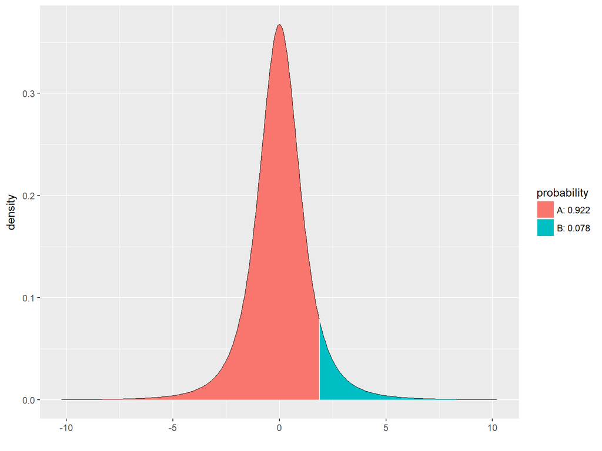

```
## [1] 0.07757725
```

```r
library(mosaic)
1 - pdist("t", q = 1.89, df = 3)
```

- O $p$-valor é 2$\cdot$ 0.078, i.e. mais do que $15$% se a hipótese alternativa for bilateral. Com base nisso, nós não rejeitamos $H_0$.

## Teste $t$ unilateral para a média

Todo o nível de significância será colocado em um lado apenas, tal como um limite inferior ou superior de confiança. Veja mais exemplos no livro do Costa Neto.

## Visão geral do teste $t$

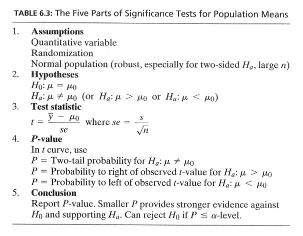

## Teste de significância para a proporção

- Considere uma amostra de tamanho $n$, onde observamos se uma determinada propriedade está presente ou não.
- A frequência relativa desta propriedade na população é $p$, estimada por $\hat{p}$.
- Hipotése Nula: $H_0: p = p_0$, onde $p_0$ é um número conhecido.
- **Alternativa bilateral**: $H_1: p \neq p_0$.
- *Se $H_0$ é verdadeira* o erro padrão $\hat{p}$ é dado por $ep_0 = \sqrt{\frac{p_0(1-p_0)}{n}}$.
- Estatística de teste observada: $z_{obs} = \frac{\hat{p}-p_0}{ep_0}$
- I.e. $z_{obs}$ mede quantos desvios padrão há entre $\hat{p}$ to $p_0$.

### Teste Aproximado

- Se $n\hat{p}$ e $n(1 - \hat{p})$ são maiores do que $5$, nós sabemos que $\hat{p}$ segue aproximadamente uma distribuição normal, i.e.
  - Se $H_0$ é verdadeira e a amostra é grande o suficiente, então $z_{obs}$ é uma observação de uma distribuição normal padrão.
- $P$-valor = 2 x “probabilidade da cauda superior de $|z_{obs}|$”. A probabilidade é calculada usando a distribuição normal padrão.

### Exemplo: Teste Aproximado

- Considere o seguinte estudo:
  - Uma amostra aleatória de 1200 indivíduos (Florida, 2006) foi consultada se preferiam menos serviços ou aumentos de impostos.
  - 52% preferiam aumentos de impostos. Isto é suficiente para dizer que a proporção é significativamente diferente de 0.5 ?
- Amostra com $n = 1200$ observações e proporção $\hat{p} = 0.52$.
- Hipotése Nula $H_0: p = 0.5$.
- Hipótese Alternativa $H_1: p \neq 0.5$.
- Erro padrão $ep_0 = \sqrt{\frac{p_0(1-p_0)}{n}} = \sqrt{\frac{0.5\times0.5}{1200}} = 0.0144$
- Estatística de teste observada $z_{obs} = \frac{\hat{p}-p_0}{ep_0}=\frac{0.52-0.5}{0.0144}=1.39$
- “A cauda superior para $1.39$” na distribuição normal padrão é 0.0823, i.e. o $p$-valor é 2$\cdot$ 0.0823$=$ 16.46%.
- Conclusão: Não há evidências suficientes para rejeitar $H_0$, i.e. nós não rejeitamos que a preferência na população é de 50%.
- Os cálculos acima também podem ser calculados automaticamente no **R** por (os resultados são um pouco diferentes, devido aos arredondamentos feitos acima):

```r
count <- 1200 * 0.52 # número de pessoas que preferem o aumento de imposto
prop.test(x = count, n = 1200, correct = F)
```

```
##
##  1-sample proportions test without continuity correction
##
## data:  count out of 1200
## X-squared = 1.92, df = 1, p-value = 0.1659
## alternative hypothesis: true p is not equal to 0.5
## 95 percent confidence interval:
##  0.4917142 0.5481581
## sample estimates:
##    p
## 0.52
```

### Teste Binomial (exato)

- Considere novamente uma amostra de tamanho $n$, onde observamos se uma determinada propriedade está presente ou não.
- A frequência relativa da propriedade na população é $p$, estimada por $\hat{p}$.
- Let $y_+=n\hat{p}$ a frequência (contagem total) da propriedade na amostra.
- Pode ser mostrado que $y_+$ segue a **distribuição binomial** com parâmetros $n$ e probabilidade de sucesso $p$. Usamos $Bin(n,p)$ para denotar esta distribuição.
- Hipótese nula: $H_0: p=p_0$, onde $p_0$ é um número conhecido.
- Hipótese alternativa: $H_1: p \neq p_0$.
- $P$-valor para o teste binomial **bilateral**:
  - Se $y_+\geq np_0$: 2 x “probabilidade na cauda superior para $y_+$ na distribuição $Bin(n,p_0)$.
  - Se $y_+< np_0$: 2 x “probabilidade na cauda superior para $y_+$” na distribuição $Bin(n,p_0)$.

### Exemplo: Teste Binomial

- Experimento com $n=30$, onde obtivemos $y_+=14$ sucessos.
- Queremos testar $H_0: p=0.3$ vs. $H_1: p \not=0.3$.
- Como $y_+>np_0=9$, usamos a probabilidade de cauda superior correspondente à soma das alturas das linhas vermelhas à direita de $14$ no gráfico abaixo. (O gráfico continua no lado direito acima de $n=30$, mas foi cortado para fins ilustrativos.)
- A probabilidade da cauda superior de $14$ para cima (i.e. maior do que $13$) é:

```r
lower_tail <- pdist("binom", q = 13, size = 30, prob = 0.3)
```

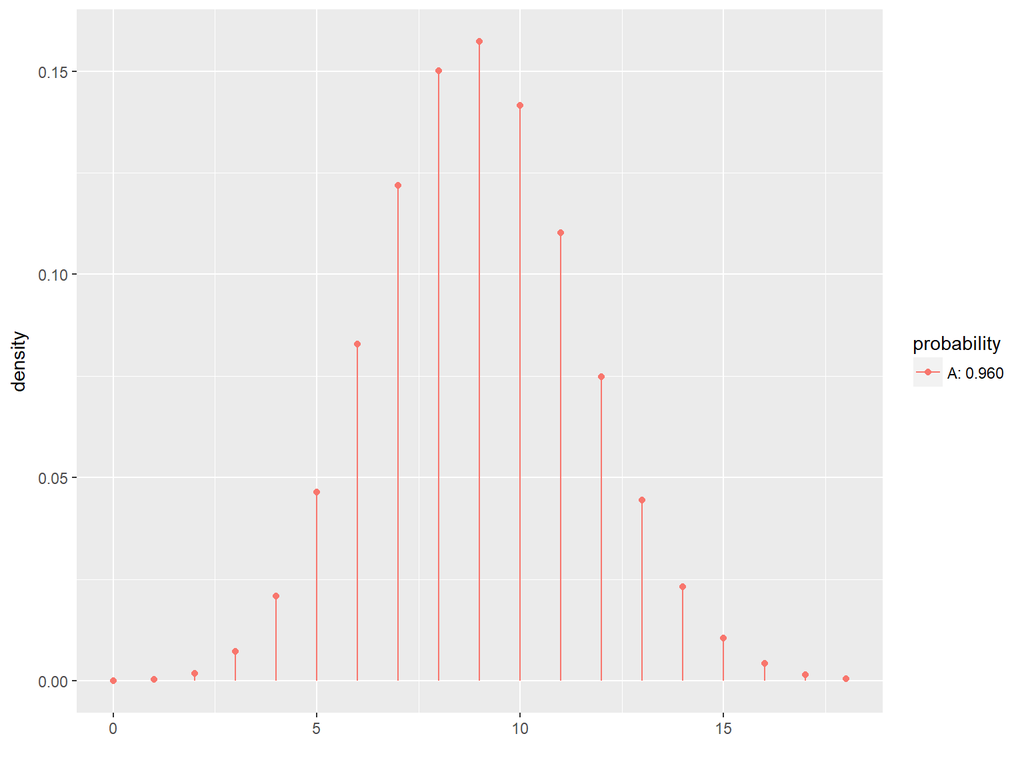

```r
1 - lower_tail
```

```
## [1] 0.04005255
```

- O $p$-valor é então 2 x 0.04 = 0.08.

### Teste Binomial no **R**

- Voltemos aos dados do Chile, onde novamente olhamos a variável `sex`.
- Vamos testar se a proporção de mulheres é diferente de 0.5, i.e., queremos testar $H_0:\ p=0.5$ and $H_1:\ p \neq 0.5$, onde $p$ é a proporção populacional desconhecida de mulheres.

```r
Chile <- read.delim("C://Users//fsabino//Desktop//Codes//papers//Introductory_Stat_II//notebook//Chile.txt")
binom.test( ~ sex, data = Chile, p = 0.5, conf.level = 0.95)
```

```
##
##
##
## data:  Chile$sex  [with success = F]
## number of successes = 1379, number of trials = 2700, p-value =
## 0.2727
## alternative hypothesis: true probability of success is not equal to 0.5
## 95 percent confidence interval:
##  0.4916971 0.5297610
## sample estimates:
## probability of success
##              0.5107407
```

- O $p$-valor para o teste exato (usando a distribuição binomial) é de $27\%$, portanto não há uma diferença significativa entre a proporção de homens e mulheres.
- O teste aproximado tem um valor $p$ de $26\%$, que pode ser calculado pelo comando

```r
prop.test( ~ sex, data = Chile, p = 0.5, conf.level = 0.95, correct = FALSE)
```

(observe o argumento adicional `correct = FALSE`).

## Visão Geral dos testes para média e proporção

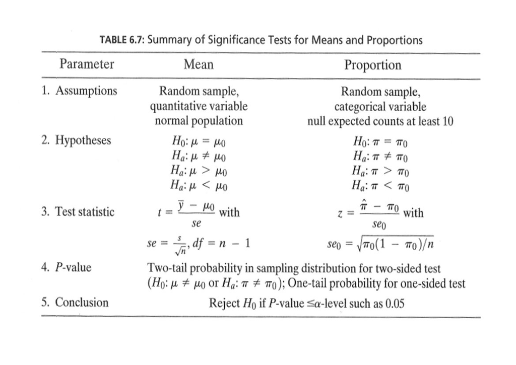

## Regressando (variável resposta) e regressores (variáveis explicativas)

- Realizamos um experimento, no qual escolhemos aleatoriamente 50 empresas de TI e 50 empresas de serviços e medimos as suas tacas de lucro. Existe associação entre o tipo de empresa (TI/serviço) e a taxa de lucro?
- Em outras palavras, nós queremos comparar amostras de 2 populações diferentes. Para cada empresa registramos:
  - A variável binária `tipo da empresa`: chamamos de **regressor ou variável explicativa**. Ela divide os dados em 2 grupos.
  - A variável quantitativa `taxa de lucro`: chamamos de **regressando ou variável resposta**.

## Amostras dependentes/independentes

- No exemplo com a taxa de lucro das 50 empresas de TI e 50 empresas de serviços, nós temos **amostras independentes**, uma vez que a mesma empresa não pode estar em ambos os grupos.
- Agora, pense em outro tipo de experimento, onde escolhemos aleatoriamente 50 empresas de TI e medimos as suas taxas de lucro em 2009 e 2010. Então, podemos estar interessados em saber se há associação entre o ano e a taxa de lucro.
- Neste exemplo, nós temos **amostras dependentes**, uma vez que a mesma companhia está em ambos os grupos.
- Nos referimos, costumeiramente, a amostras dependentes como **amostras pareadas**.

## Comparação de 2 médias

- Consideremos a situação em que temos duas amostras de variáveis quantitativas:
  - População $1$ tem média $\mu_1$, que é estimada por $\hat{\mu}_1=\bar{y}_1$ com base em uma amostra de tamanho $n_1$.
  - População 2 tem média $\mu_2$, que é estimada por $\hat{\mu}_2=\bar{y}_2$ com base em uma amostra de tamanho $n_2$.
  - Estamos interessados na diferença $\mu_2-\mu_1$, que é estimada por $d=\bar{y}_2-\bar{y}_1$.
  - Suponha que queremos encontrar o **eerro padrão estimado** $ep_d$ da diferença e que isto tem $df$ graus de liberdade.
  - Suponha que as amostras sejam grandes ou que sejam provenientes de populações com distribuição normal.
- Então podemos construir um
  - intervalo de confiança para a diferença, i.e.,
    $$(\bar{y}_2-\bar{y}_1)\pm t_{crit}ep_d,$$
    onde o escore crítico $t$, $t_{crit}$, determina o nível de confiança.
  - teste de significância:
    - para a hipótese nula $H_0:\ \mu_2-\mu_1=0$ e a hipótese alternativa $H_1:\ \mu_2-\mu_1\neq 0$.
    - usamos a estatística de teste: $t_{obs} = \frac{\bar{y}_2-\bar{y}_1}{ep_d}$, que tem que ser avaliada em uma distribuição $t$ com $df$ graus de liberdade.

## Comparação de duas médias: Amostras independentes

- Na situação em que as amostras são independentes pode ser demonstrado que
  $$ep_d=\sqrt{ep_1^2+ep_2^2},$$
  onde $ep_1$ e $ep_2$ são erros padrão estimados para as médias amostrais nas populações $1$ e 2, respectivamente.
- Relembre que neste caso nós temos $ep=\frac{s}{\sqrt{n}}$, i.e.
  $$ep_d=\sqrt{\frac{s_1^2}{n_1}+\frac{s_2^2}{n_2}},$$
  onde $s_1$ e $s_2$ são desvios padrão estimados para as populações $1$ e 2, respectivamente.
- Veja os **graus de liberdade** no capítulo 5 de Costa Neto.

## Exemplo: Comparando duas médias (amostras independentes)

Voltamos aos dados do `Chile`. Nós estudamos a associação entre as variáveis `sex` e `statusquo`. Vamos, então, fazer um teste de significância para testar a diferença entre as médidas de `statusquo` para homens e mulheres.

```r
Chile <- read.delim("C://Users//fsabino//Desktop//Codes//papers//Introductory_Stat_II//notebook//Chile.txt")
library(mosaic)
fv <- favstats(statusquo ~ sex, data = Chile)
fv
```

```
##   sex   min     Q1 median    Q3  max    mean    sd    n missing
## 1   F -1.80 -0.975  0.121 1.033 2.02  0.0657 1.003 1368      11
## 2   M -1.74 -1.032 -0.216 0.861 2.05 -0.0684 0.993 1315       6
```

- Diferença: $d = 0.0657 - (-0.0684) = 0.1341$.
- Desvio padrão estimado: $s_1 = 1.0032$ (mulheres) and $s_2 = 0.9928$ (homens).
- Tamanhos amostrais: $n_1 = 1368$ e $n_2 = 1315$.
- Erro padrão estimado da diferença: $ep_d = \sqrt{\frac{s_1^2}{n_1} + \frac{s_2^2}{n_2}} = \sqrt{\frac{1.0032^2}{1368} + \frac{0.9928^2}{1315}} = 0.0385$.
- $t$-escore observado para $H_0:\ \mu_1-\mu_2=0$ é: $\quad t_{obs} = \frac{d-0}{ep_d} = \frac{0.1341}{0.0385} = 3.4786$.
- Como os tamanhos das amostras são “grandes”, nós podemos usar o escore-$z$ ao invés do escore-$t$ para encontrar o $p$-valor aproximado:

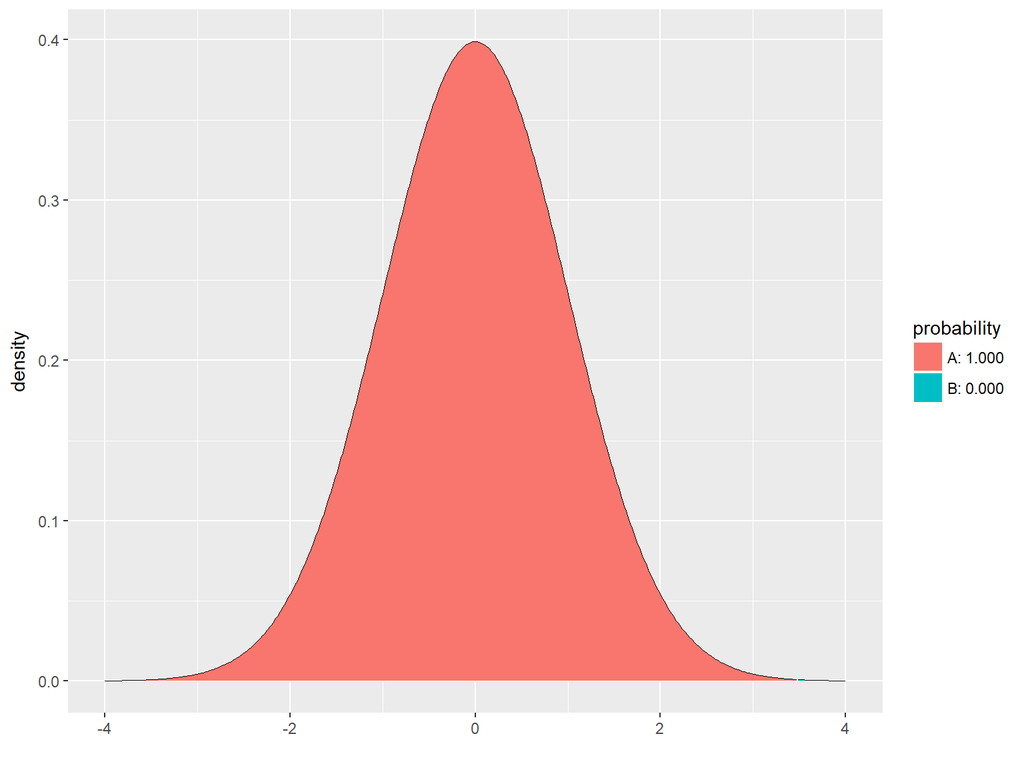

```
## [1] 0.0002520202
```

```r
1 - pdist("norm", q = 3.4786, xlim = c(-4, 4))
```

- Então o $p$-valor é $2\cdot 0.00025 = 0.0005$, e, portanto, nós rejeitamos a hipótese nula.
- Podemos deixar todos os cálculos para o **R** usando `t.test`:

```r
t.test(statusquo ~ sex, data = Chile)
```

```
##
##  Welch Two Sample t-test
##
## data:  statusquo by sex
## t = 3.4786, df = 2678.7, p-value = 0.0005121
## alternative hypothesis: true difference in means is not equal to 0
## 95 percent confidence interval:
##  0.05849179 0.20962982
## sample estimates:
## mean in group F mean in group M
##      0.06570627     -0.06835453
```

- Nós reconhecemos o escore-$t$ $3.4786$ e o $p$-valor $0.0005$. Os graus de liberdade $df = 2679$ são grandes e neste caso os resultados obtidos utilizando os escores-$z$ e $t$ são muito similares.

## Comparação entre duas médias: intervalo de confiança (amostras independentes)

- Nós já temos todos os “ingredientes” para construir um **intervalo de confiança para $\mu_2-\mu_1$**:
  - $d=\bar{y}_2-\bar{y}_1$ é um estimador por pornto para $\mu_2-\mu_1$.
  - $ep_d=\sqrt{\frac{s_1^2}{n_1}+\frac{s_2^2}{n_2}}$ é um estimador por ponto para o erro padrão de $d$.
- Then:
  $$d\pm t_{crit}ep_d$$
  é um intervalo de confiança para $\mu_2-\mu_1$.
- O escore-$t$ crítico, $t_{crit}$ é escolhido de acordo com o nível de confiança desejado.

## Comparação entre duas médias: teste-$t$ pareado (amostras dependentes)

- Experimento:
  - Você escolhe $10$ supermercados Zaffari/Nacional (ou outro) aleatoriamente, e mede o tempo médio de serviço das caixas registradoras durante algum período de tempo.
  - Agora, novas caixas registradoras são instaladas nos $10$ supermercados e você repete o experimento.
- É interessante investigar se as novas caixas registradoras mudaram ou não o tempo médio de serviço.
- Portanto, nós temos 2 amostras correspondentes à tecnologia nova e antiga. Neste caso, as amostras são **dependentes**, já que temos duas medições em cada loja (assuma que outras variáveis sejam mantidas fixas).
- Usamos a seguinte estratégia para análise:
  - Para cada loja calcule **a mudança** no tempo médio de serviço quando mudamos da tecnologia antiga para a nova.
  - As alterações $d_1,d_2,\ldots,d_{10}$ formam **UMA** amostra de uma população com média $\mu$.
  - Teste a hipótese $H_0: \mu=0$ como de costume (usando um teste-$t$-test para testar a média).

### Exemplo do Supermercado

- Os dados são organizados em um “data frame” com 2 variáveis, `before` e `after`, contendo o tempo médio de serviço antes e depois da instalação da nova tecnologia. Ao invés de fazer cálculos manuais, nós deixamos o **R** executar o teste de significância (usando `t.test` com `paired = TRUE` dado que as nossas amostras são emparelhadas/dependentes):

```r
super <- read.delim("C://Users//fsabino//Desktop//Codes//papers//Introductory_Stat_II//notebook//supermarket.txt")
head(super, n = 3)
```

```
##     before    after
## 1 3.730611 3.440214
## 2 2.623338 2.314733
## 3 3.795295 3.586334
```

```r
t.test(super$before, super$after, paired = TRUE)
```

```
##
##  Paired t-test
##
## data:  super$before and super$after
## t = 5.7204, df = 9, p-value = 0.0002868
## alternative hypothesis: true difference in means is not equal to 0
## 95 percent confidence interval:
##  0.1122744 0.2591578
## sample estimates:
## mean of the differences
##               0.1857161
```

- Com um $p$-valor de $0.00029$, nós rejeitamos que o tempo médio de serviço seja o mesmo após a instalação da nova tecnologia.

# Comparação de duas proporções

## Comparação de duas proporções

- Considere a situação em que temos amostras de duas variáveis qualitativas e queremos investigar se uma determinada propriedade está presente ou não:
  - Seja a proporção da população $1$ igual $p_1$, estimada por $\hat{p}_1$ com base em uma amostra de tamanho $n_1$.
  - Seja a proporção da população 2 igual $p_2$, estimada por $\hat{p}_2$ com base em uma amostra de tamanho $n_2$.
  - Nós estamos interessados na diferença $p_2-p_1$, que é estimada por $d=\hat{p}_2-\hat{p}_1$.
  - Calculando o **erro padrão estimado** $ep_d$ da diferença, nós podemos:
- Construir um
  - intervalo de confiança aproximado para a diferença, $p_2 - p_1$.
  - um teste de significância.

## Comparação de duas proporções: Amostras independentes

- Na situação em que temos amostras independentes, nós sabemos que
  $$ep_d=\sqrt{ep_1^2+ep_2^2},$$
  onde $ep_1$ e $ep_2$ são os erros padrão estimados para as proporções amostrais na população $1$ e 2, respectivamente.
- Relembre que estes erros padrão são $ep=\sqrt{\frac{\hat{p}(1-\hat{p})}{n}}$, e, portanto,
  $$ep_d = \sqrt{\frac{\hat{p}_1(1-\hat{p}_1)}{n_1}+\frac{\hat{p}_2(1-\hat{p}_2)}{n_2}}.$$
- Um intervalo de confiança (aproximado) para $p_2-p_1$ é obtido pela construção usual:
  $$(\hat{p}_2-\hat{p}_1)\pm z_{crit}ep_d,$$
  onde o escore-$z$ crítico determina o nível de confiança.

## Teste aproximado para comparar duas proporções (amostras independentes)

- Considere a hipótese nula $H_0$: $p_1=p_2$ (equivalentemente $H_0: p_1 - p_2 = 0$) e a hipótese alternativa $H_1$: $p_1 \neq p_2$.
- Assumindo que $H_0$ é verdadeira, nós temos uma proporção comum $p$, que é estimada por
  $$\hat{p}=\frac{n_1\hat{p}_1+n_2\hat{p}_2}{n_1+n_2},$$
  i.e. nós agregamos as populações e calculamos a frequência relativa da propriedade (em outras palavras: nós estimamos a proporção, $p$, como se as duas amostras fossem uma só).
- Em vez de usar o erro padrão estimado da diferença como anteriormente, nós estimamos da seguinte maneira sob $H_0$:
  $$ep_0=\sqrt{\hat{p}(1-\hat{p})\left(\frac{1}{n_1}+\frac{1}{n_2}\right)}$$
- A estatística de teste observada (escore-$z$) sob $H_0$ é então:
  $$z_{obs}=\frac{\hat{p}_2-\hat{p}_1}{ep_0}.$$

**ATENçÃO**: A aproximação só será boa se o tamanho da amostra for grande o suficiente. Costuma-se considerar como tal quando $n_1\hat{p},\ n_1(1-\hat{p}),\ n_2\hat{p},\ n_2(1-\hat{p})$ são todos maiores do que 5.

## Exemplo: Intervalo de confiança aproximado e teste para comparação de proporções

Voltemos ao conjunto de dados do `Chile`. Seja uma variável binária indicando se a pessoa pretende votar não (no **R** devemos informar que se trata de um fator - `factor`):

```r
Chile$voteNo <- relevel(factor(Chile$vote == "N"), ref = "TRUE")
```

Nós estudamos a associação entre as variáveis `sex` e `voteNo`:

```r
tab <- tally( ~ sex + voteNo, data = Chile, useNA = "no")
tab
```

```
##    voteNo
## sex TRUE FALSE
##   F  363   946
##   M  526   697
```

Isto nos dá todos os ingredientes necessários para fazer o teste de hipóteses:

- proporção estimada de homens que votam não: $\hat{p}_1=\frac{526}{526+697}=0.430$
- proporção estimada de mulheres que votam não: $\hat{p}_2=\frac{363}{363+946}=0.277$
- proporção comum estimada: $\hat{p}=\frac{1223 \times 0.430 + 1309 \times 0.277}{1309+1223}=\frac{526 + 363}{1309+1223}=0.351.$
- diferença estimada $d=\hat{p}_2-\hat{p}_1=0.277-0.430=-0.153$

Além disso,

- Erro padrão da diferença:  
  $ep_d=\sqrt{\frac{\hat{p}_1(1-\hat{p}_1)}{n_1}+\frac{\hat{p}_2(1-\hat{p}_2)}{n_2}} = \sqrt{\frac{0.430(1-0.430)}{1223}+\frac{0.277(1-0.277)}{1309}}= 0.0188$.
- Intervalo de confiança (aproximado) 95% para a diferença: $d\pm 1.96ep_d=(-0.190, -0.116)$.
- Erro padrão da diferença quando $H_0:\ p_1=p_2$ é verdadeira:  
  $ep_0=\sqrt{\hat{p}(1-\hat{p})(\frac{1}{n_1}+\frac{1}{n_2})} = 0.0190$.
- A estatística de teste observada/escore-$z$ é: $z_{obs}=\frac{d}{ep_0}=-8.06$. O teste para $H_0$ versus $H_1: p_1\not=p_2$ encontra um $p$-valor que é praticamente zero, i.e. podemos rejeitar que as proporções sejam iguais (com base nesta amostra temos fortes evidências de que elas não são iguais).

### Cálculo automático no **R**

```r
Chile2 <- subset(Chile, !is.na(voteNo))
prop.test(voteNo ~ sex, data = Chile2, correct = FALSE)
```

```
##
##  2-sample test for equality of proportions without continuity
##  correction
##
## data:  tally(voteNo ~ sex)
## X-squared = 64.777, df = 1, p-value = 8.389e-16
## alternative hypothesis: two.sided
## 95 percent confidence interval:
##  -0.1896305 -0.1159275
## sample estimates:
##    prop 1    prop 2
## 0.2773109 0.4300899
```

## Teste exato de Fisher

- Se $n_1\hat{p},\ n_1(1-\hat{p}),\ n_2\hat{p},\ n_2(1-\hat{p})$ não são todos maiores do que 5, então o teste aproximado não é confiável. Ao invés disso, você pode usar o teste exato de Fisher:

```r
fisher.test(tab)
```

```
##
##  Fisher's Exact Test for Count Data
##
## data:  tab
## p-value = 1.04e-15
## alternative hypothesis: true odds ratio is not equal to 1
## 95 percent confidence interval:
##  0.4292768 0.6021525
## sample estimates:
## odds ratio
##  0.5085996
```

- O $p$-valor é extremamente pequeno, rejeitando definitivamente a hipótese nula de igualdade de proporções entre homens e mulheres.

## Visão geral da comparação de 2 grupos

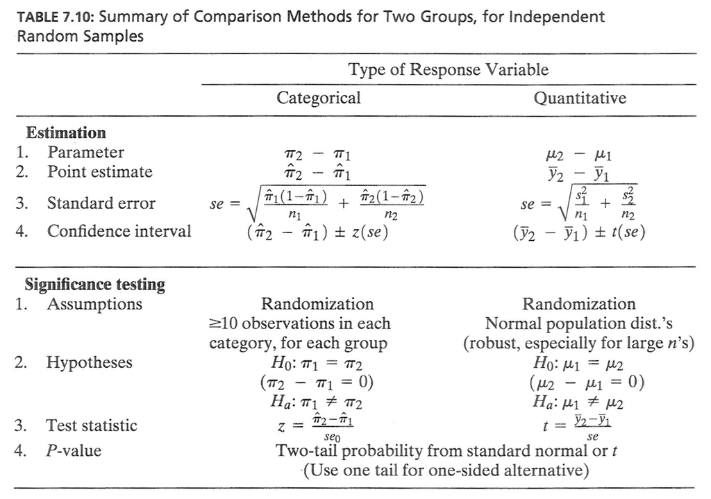

## Costa Neto

Continuaremos agora o estudo utilizando o capítulo 5 do livro do Costa Neto.

- Erros do Tipo I e II, Poder do Teste
- Testes de uma Média Populacional com $\sigma$ conhecido
- Testes de uma Média Populacional com $\sigma$ desconhecido
- Testes de uma variância populacional
- Testes de uma proporção populacional, Correção de Continuidade
- Comparação de duas Médias (Amostras Independentes - desvios conhecidos, desconhecidos - e Pareadas)
- Comparação de duas Variâncias
- Comparação de duas Proporções
- Intervalo de Confiança para a Diferença entre Parâmetros
- Tamanhos das amostras

Refaça os exemplos e pelo menos os exercícios com resposta resumida no final do livro: 3, 5, 7, 10, 14, 15, 16, 19, 25, 26, 34 e 35.

## Resumo

Ao final deste estudo você deve:

- Saber definir qual a hipótese nula relevante e a alternativa correspondente
- Escolher adequadamente e calcular a estatística de teste
- Calcular o p-valor, interpretá-lo e estar apto para tomar a decisão e concluir a análise
- Calcular e interpretar os intervalos de confiança
- Determinar o tamanho da amostra quando a amostragem é aleatória simples